# Covid-19 Mental Health

## Load packages

```r
library(zoo) # moving averages
library(plyr)
library(tidyverse)
library(readxl)
library(tibbletime)
library(lubridate)
```

Observational period between March 5 and September 5, 2020

```r
# volume data
cmh_ed <- read_excel('data/ED Volume Cambridge.xlsx')
grh_ed <- read_excel('data/ED volumes GRH.xlsx')
smh_ed <- read_excel('data/ED volumes SMH.xlsx')

# mental health data
cmh_mh <- read_excel('data/COVID-19 data sheet edited Jan 23.xlsx', sheet='cmh') %>%
  replace(is.na(.), 0) %>%
  pivot_longer(cols = `March 1 - March 7`:`August 30th - September 5th`,
               names_to='week',
               values_to='count')

grh_mh <- read_excel('data/COVID-19 data sheet edited Jan 23.xlsx', sheet='grh') %>%
  replace(is.na(.), 0) %>%
  pivot_longer(cols = `March 1 - March 7`:`August 30th - September 5th`,
               names_to='week',
               values_to='count')

smh_mh <- read_excel('data/COVID-19 data sheet edited Jan 23.xlsx', sheet='smh') %>%
  replace(is.na(.), 0) %>%
  pivot_longer(cols = `March 1 - March 7`:`August 30th - September 5th`,
               names_to='week',
               values_to='count')

# Police data
pol <- read_excel('data/COVID-19 data sheet edited Jan 23.xlsx', sheet='pol') %>%
  filter(Subtype!='Drug overdose (monthly totals)' & Type!='EMS data') %>%
  mutate(`June 21 - June 27`=as.double(`June 21 - June 27`)) %>%
  replace(is.na(.), 0) %>%
  pivot_longer(cols = `March 1 - March 7`:`August 30th - September 5th`,
               names_to='week',
               values_to='count')
```

## Figure 1

Get total volume

```r
vol <- smh_ed %>% left_join(grh_ed, by=c("Date of ED visit (reg)" = "Day of Triage_DT")) %>%
  left_join(cmh_ed, by=c("Date of ED visit (reg)" = "Triage Date")) %>%
  rename(date=`Date of ED visit (reg)`, smh=`# of cases`, grh=`Number of Records`, cmh=Volume) %>%
  mutate(total=smh+grh+cmh) %>%
  mutate(year=as.factor(year(date)))
```

```r
vol %>%
  group_by(year) %>%
  summarize(sum(total))
```

| year | sum(total) |
| --- | --- |
| 2019 | 89800 |
| 2020 | 69877 |
| NA | NA |

```r
rbind(cmh_mh, grh_mh, smh_mh) %>%
  group_by(Year) %>%
  summarize(sum(count))
```

| Year | sum(count) |
| --- | --- |
| 2019 | 11045 |
| 2020 | 8674 |

ED visits during lockdown  
Line graph

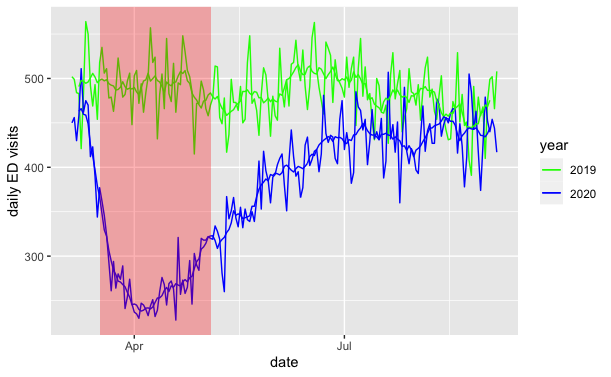

```r
vol <- vol %>% drop_na() %>%
  group_by(year) %>%
  mutate(roll = rollmean(total, k = 7, fill = NA)) %>%
  mutate(date = if_else(year==2019, date+years(1), date))
p <- ggplot(vol, aes(x=date, y=total, color=year)) +
  geom_line() +
  geom_line(aes(x=date, y=roll)) +
  scale_color_manual(values=c("green", "blue")) +
  ylab('daily ED visits') +
  annotate('rect', xmin=as.POSIXct('2020-03-17'), xmax=as.POSIXct('2020-05-04'),
           ymin=-Inf, ymax=Inf, fill='red', alpha=0.3)
ggsave('graphs/vol.png', p, height = 8.5, width = 11, units = 'in')
p
```

```r
v2020 <- vol %>%
  filter(year==2020)
max <- max(v2020$roll, na.rm = TRUE)
v2020$date[v2020$roll==max(v2020$roll, na.rm = TRUE)]
```

```
[1] NA               NA               NA               "2020-03-09 UTC"
[5] NA               NA               NA
```

```r
min <- min(v2020$roll, na.rm = TRUE)
v2020$date[v2020$roll==min(v2020$roll, na.rm = TRUE)]
```

```
[1] NA               NA               NA               "2020-04-04 UTC"
[5] NA               NA               NA
```

```r
(max-min)/max
```

```
[1] 0.4889638
```

Histogram (for potential ANOVA)

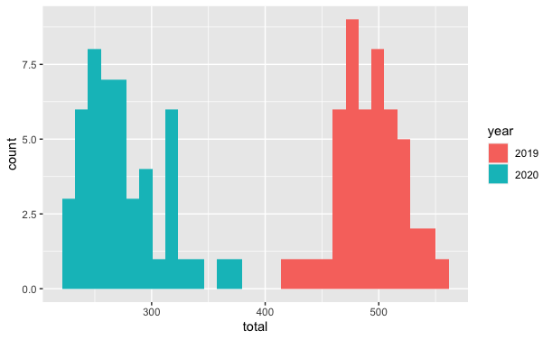

```r
vol %>% mutate(date=as.Date(date)) %>%
  filter(date>='2019-03-17' & date<='2020-05-04') %>%
  filter(date<='2019-05-04' | date>='2020-03-17') %>%
  ggplot(aes(x=total, fill=year)) +
  geom_histogram()
```

Poisson ED visits during lockdown

We’re looking at the difference in outcome (hospitalizations) based on at least one predictor (year). That’s general linear model territory. If you are summarizing over some period (e.g., the average across the shaded area), then the formulation of GLM that we refer to as ANOVA for shorthand would probably be OK. If you are not summarizing, and are using the individual data points, then you’ll be violating some of the assumptions of GLM – our observations are not independent, because the rate on Oct 2 is more related to the rate on Oct 3 than it is to April 3 (for example). In other words, these are time series data, where there is a trend happening, and to ignore that would violate the assumption of (residual) independence.

Second, we might be violating the assumption that our residuals are normally distributed, because we know this type of data (counts) has been drawn from something other than a normal distribution, because only integers are possible and the counts are bounded at zero (normal distribution has limits of +/- infinity). So, we should be thinking about altering our GLM to expect a different distribution, like Poisson. However, it turns out that because the big problem with count data is the boundary at zero, when our counts are all far away from zero, the results of a model where we assume a normal distribution and where we assume a Poisson distribution converge. In the normal distribution, you get decimal points in your estimate, which don’t really make sense (can’t have half an ER visit), but this can easily be ignored. If you can live with that, then you might do the ANOVA. But, if you can stomach it, Poisson is the more correct version.

In summary, can’t use ANOVA because it violates two assumptions:  
1. The observations are not independent  
2. The residuals are not normally distributed

We use Poisson regression because:  
1. It can handle observations that are not independent  
2. Counts are drawn from something other than a normal distribution, i.e. a Poisson distribution

Before starting to interpret results, let’s check whether the model has over-dispersion or under-dispersion. If the Residual Deviance is greater than the degrees of freedom, then over-dispersion exists. This means that the estimates are correct, but the standard errors (standard deviation) are wrong and unaccounted for by the model.

So, to have a more correct standard error we can use a quasi-poisson model:

```r
volume <- vol %>% mutate(date=as.Date(date)) %>%
  filter(date>='2019-03-17' & date<='2020-05-04') %>%
  filter(date<='2019-05-04' | date>='2020-03-17')

# Poisson regression
poisson_vol <- glm(total ~ year, family='quasipoisson', data=volume)
fig1 <- data.frame(coef(summary(poisson_vol))) %>%
  slice(2) %>%
  rename(`p-val(t)`=Pr...t..)
write_csv(fig1, 'stat_tests/fig1.csv')
summary(poisson_vol)
```

```
Call:
glm(formula = total ~ year, family = "quasipoisson", data = volume)

Deviance Residuals:
    Min       1Q   Median       3Q      Max
-3.5631  -1.1773  -0.2203   0.8791   5.8092

Coefficients:
            Estimate Std. Error t value Pr(>|t|)
(Intercept)  6.19823    0.01149  539.63   <2e-16 ***
year2020    -0.58087    0.01918  -30.29   <2e-16 ***
---
Signif. codes:  0 ‘***’ 0.001 ‘**’ 0.01 ‘*’ 0.05 ‘.’ 0.1 ‘ ’ 1

(Dispersion parameter for quasipoisson family taken to be 3.179813)

    Null deviance: 3340.10  on 97  degrees of freedom
Residual deviance:  298.63  on 96  degrees of freedom
AIC: NA

Number of Fisher Scoring iterations: 4
```

## Figure 2

Lockdown: 3/17 - 5/4 Weeks:

```r
get_data <- function(data, type, subtype=NULL) {
  weeks <- c('March 15 - March 21\r\n\r\n', 'Mar 22 - Mar 28', 'Mar 29 - Apr 4', 'April 5 - 11', 'April 12 - 18', 'April 19 - 25', 'April 26 - May 2')
  if (is.null(subtype)) {
    smh <- data$smh_mh %>%
      filter(week %in% weeks) %>%
      filter(Type==type) %>%
      group_by(Year, week) %>%
      summarize(count=sum(count)) %>%
      mutate(date=paste(week, Year, sep=' '))
    grh <- data$grh_mh %>%
      filter(week %in% weeks) %>%
      filter(Type==type) %>%
      group_by(Year, week) %>%
      summarize(count=sum(count)) %>%
      mutate(date=paste(week, Year, sep=' '))
    cmh <- data$cmh_mh %>%
      filter(week %in% weeks) %>%
      filter(Type==type) %>%
      group_by(Year, week) %>%
      summarize(count=sum(count)) %>%
      mutate(date=paste(week, Year, sep=' '))
  } else {
    smh <- data$smh_mh %>%
      filter(week %in% weeks) %>%
      filter(Type==type, Subtype==subtype) %>%
      group_by(Year, week) %>%
      summarize(count=sum(count)) %>%
      mutate(date=paste(week, Year, sep=' '))
    grh <- data$grh_mh %>%
      filter(week %in% weeks) %>%
      filter(Type==type, Subtype==subtype) %>%
      group_by(Year, week) %>%
      summarize(count=sum(count)) %>%
      mutate(date=paste(week, Year, sep=' '))
    cmh <- data$cmh_mh %>%
      filter(week %in% weeks) %>%
      filter(Type==type, Subtype==subtype) %>%
      group_by(Year, week) %>%
      summarize(count=sum(count)) %>%
      mutate(date=paste(week, Year, sep=' '))
  }
  whole <- smh %>%
    left_join(grh, by='date') %>%
    left_join(cmh, by='date') %>%
    mutate(total=count+count.x+count.y) %>%
    select(Year, week, total) %>%
    mutate(Year=as.factor(Year))
  return(whole)
}
```

Mental health data

```r
mh <- list(smh_mh=smh_mh, grh_mh=grh_mh, cmh_mh=cmh_mh)
```

Involuntary - Form 1

```r
involuntary <- get_data(mh, 'Form 1 Total')
# Poisson regression
poisson_inv <- glm(total ~ Year, data=involuntary, family='poisson')
summary(poisson_inv)
```

```
Call:
glm(formula = total ~ Year, family = "poisson", data = involuntary)

Deviance Residuals:
    Min       1Q   Median       3Q      Max
-1.7764  -0.8279  -0.2240   0.5273   3.4294

Coefficients:
            Estimate Std. Error z value Pr(>|z|)
(Intercept)  5.06801    0.02999  169.00   <2e-16 ***
Year2020    -0.52016    0.04911  -10.59   <2e-16 ***
---
Signif. codes:  0 ‘***’ 0.001 ‘**’ 0.01 ‘*’ 0.05 ‘.’ 0.1 ‘ ’ 1

(Dispersion parameter for poisson family taken to be 1)

    Null deviance: 138.481  on 13  degrees of freedom
Residual deviance:  22.489  on 12  degrees of freedom
AIC: 119.47

Number of Fisher Scoring iterations: 4
```

Substance related

```r
substance <- get_data(mh, 'Substance related', 'Substance misuse/abuse')
# Poisson regression
poisson_sub <- glm(total ~ Year, data=substance, family='quasipoisson')
summary(poisson_sub)
```

```
Call:
glm(formula = total ~ Year, family = "quasipoisson", data = substance)

Deviance Residuals:
    Min       1Q   Median       3Q      Max
-3.5606  -1.1470  -0.4248   0.7334   7.1166

Coefficients:
            Estimate Std. Error t value Pr(>|t|)
(Intercept)   4.0355     0.1418  28.457  2.2e-12 ***
Year2020     -0.7829     0.2532  -3.092  0.00932 **
---
Signif. codes:  0 ‘***’ 0.001 ‘**’ 0.01 ‘*’ 0.05 ‘.’ 0.1 ‘ ’ 1

(Dispersion parameter for quasipoisson family taken to be 7.96348)

    Null deviance: 165.335  on 13  degrees of freedom
Residual deviance:  83.257  on 12  degrees of freedom
AIC: NA

Number of Fisher Scoring iterations: 4
```

Alcohol Related

```r
alcohol <- get_data(mh, 'Substance related', 'Alcohol (separate)')
# Poisson regression
poisson_alc <- glm(total ~ Year, data=alcohol, family='quasipoisson')
summary(poisson_alc)
```

```
Call:
glm(formula = total ~ Year, family = "quasipoisson", data = alcohol)

Deviance Residuals:
    Min       1Q   Median       3Q      Max
-3.2806  -1.1763  -0.4759   0.4159   7.7236

Coefficients:
            Estimate Std. Error t value Pr(>|t|)
(Intercept)   3.5756     0.1958  18.265 4.01e-10 ***
Year2020     -0.7012     0.3400  -2.062   0.0615 .
---
Signif. codes:  0 ‘***’ 0.001 ‘**’ 0.01 ‘*’ 0.05 ‘.’ 0.1 ‘ ’ 1

(Dispersion parameter for quasipoisson family taken to be 9.58071)

    Null deviance: 136.99  on 13  degrees of freedom
Residual deviance:  93.70  on 12  degrees of freedom
AIC: NA

Number of Fisher Scoring iterations: 5
```

Mood related

```r
mood <- get_data(mh, 'Mood related')
# Poisson regression
poisson_mood <- glm(total ~ Year, data=mood, family='quasipoisson')
summary(poisson_mood)
```

```
Call:
glm(formula = total ~ Year, family = "quasipoisson", data = mood)

Deviance Residuals:
    Min       1Q   Median       3Q      Max
-1.5245  -0.8072  -0.1948   0.6147   1.9522

Coefficients:
            Estimate Std. Error t value Pr(>|t|)
(Intercept)  4.30599    0.04709  91.447  < 2e-16 ***
Year2020    -0.73044    0.08258  -8.845 1.33e-06 ***
---
Signif. codes:  0 ‘***’ 0.001 ‘**’ 0.01 ‘*’ 0.05 ‘.’ 0.1 ‘ ’ 1

(Dispersion parameter for quasipoisson family taken to be 1.150723)

    Null deviance: 109.70  on 13  degrees of freedom
Residual deviance:  13.58  on 12  degrees of freedom
AIC: NA

Number of Fisher Scoring iterations: 4
```

Psychosis related

```r
psychosis <- get_data(mh, 'Psychosis related')
# Poisson regression
poisson_psy <- glm(total ~ Year, data=psychosis, family='quasipoisson')
summary(poisson_psy)
```

```
Call:
glm(formula = total ~ Year, family = "quasipoisson", data = psychosis)

Deviance Residuals:
    Min       1Q   Median       3Q      Max
-2.0666  -0.5443   0.1913   0.7270   1.2945

Coefficients:
            Estimate Std. Error t value Pr(>|t|)
(Intercept)  3.17208    0.08012  39.590 4.35e-14 ***
Year2020     0.12375    0.10996   1.125    0.282
---
Signif. codes:  0 ‘***’ 0.001 ‘**’ 0.01 ‘*’ 0.05 ‘.’ 0.1 ‘ ’ 1

(Dispersion parameter for quasipoisson family taken to be 1.072078)

    Null deviance: 14.778  on 13  degrees of freedom
Residual deviance: 13.418  on 12  degrees of freedom
AIC: NA

Number of Fisher Scoring iterations: 4
```

Situational crisis

```r
situational <- get_data(mh, 'Situational crisis')
# Poisson regression
poisson_sit <- glm(total ~ Year, data=situational, family='poisson')
summary(poisson_sit)
```

```
Call:
glm(formula = total ~ Year, family = "poisson", data = situational)

Deviance Residuals:
     Min        1Q    Median        3Q       Max
-1.36899  -0.82692   0.07681   0.53286   1.14012

Coefficients:
            Estimate Std. Error z value Pr(>|z|)
(Intercept)  3.14784    0.07833  40.189  < 2e-16 ***
Year2020    -0.99941    0.15100  -6.618 3.63e-11 ***
---
Signif. codes:  0 ‘***’ 0.001 ‘**’ 0.01 ‘*’ 0.05 ‘.’ 0.1 ‘ ’ 1

(Dispersion parameter for poisson family taken to be 1)

    Null deviance: 59.4194  on 13  degrees of freedom
Residual deviance:  9.9905  on 12  degrees of freedom
AIC: 76.622

Number of Fisher Scoring iterations: 4
```

Self harm related

```r
harm <- get_data(mh, 'Self harm')
# Poisson regression
poisson_harm <- glm(total ~ Year, data=harm, family='poisson')
summary(poisson_harm)
```

```
Call:
glm(formula = total ~ Year, family = "poisson", data = harm)

Deviance Residuals:
     Min        1Q    Median        3Q       Max
-1.30384  -0.43227  -0.06595   0.40137   1.55330

Coefficients:
            Estimate Std. Error z value Pr(>|z|)
(Intercept)   2.2285     0.1240  17.967   <2e-16 ***
Year2020     -0.4608     0.1994  -2.311   0.0209 *
---
Signif. codes:  0 ‘***’ 0.001 ‘**’ 0.01 ‘*’ 0.05 ‘.’ 0.1 ‘ ’ 1

(Dispersion parameter for poisson family taken to be 1)

    Null deviance: 12.8168  on 13  degrees of freedom
Residual deviance:  7.3354  on 12  degrees of freedom
AIC: 64.818

Number of Fisher Scoring iterations: 4
```

```r
get_fig2 <- function(poisson_fig2) {
  inv <- data.frame(coef(summary(poisson_fig2$poisson_inv))) %>%
    slice(2) %>%
    select(z.value, Pr...z..)
  sub <- data.frame(coef(summary(poisson_fig2$poisson_sub))) %>%
    slice(2) %>%
    select(t.value, Pr...t..)
  alc <- data.frame(coef(summary(poisson_fig2$poisson_alc))) %>%
    slice(2) %>%
    select(t.value, Pr...t..)
  mood <- data.frame(coef(summary(poisson_fig2$poisson_mood))) %>%
    slice(2) %>%
    select(t.value, Pr...t..)
  psy <- data.frame(coef(summary(poisson_fig2$poisson_psy))) %>%
    slice(2) %>%
    select(t.value, Pr...t..)
  sit <- data.frame(coef(summary(poisson_fig2$poisson_sit))) %>%
    slice(2) %>%
    select(z.value, Pr...z..)
  harm <- data.frame(coef(summary(poisson_fig2$poisson_harm))) %>%
    slice(2) %>%
    select(z.value, Pr...z..)

  tot <- rbind.fill(inv, sub, alc, mood, psy, sit, harm)
  tot$type <- c('Involuntary - Form 1', 'Substance related', 'Alcohol related', 'Mood related', 'Psychosis related', 'Situational crisis', 'Self harm related')
  tot <- tot %>%
    rename(`p-val(z)`=Pr...z.., `p-val(t)`=Pr...t..)
  return(tot)
}
```

```r
poisson_fig2 <- list(poisson_inv=poisson_inv, poisson_sub=poisson_sub, poisson_alc=poisson_alc, poisson_mood=poisson_mood, poisson_psy=poisson_psy, poisson_sit=poisson_sit, poisson_harm=poisson_harm)
```

```r
fig2 <- get_fig2(poisson_fig2)
write_csv(fig2, 'stat_tests/fig2.csv')
```

## Figure 3

```r
weeks <- c('March 15 - March 21\r\n\r\n', 'Mar 22 - Mar 28', 'Mar 29 - Apr 4', 'April 5 - 11', 'April 12 - 18', 'April 19 - 25', 'April 26 - May 2')
```

Suicide

```r
suicide <- pol %>%
  filter(week %in% weeks) %>%
  filter(Subtype=='Suicide attempt') %>%
  group_by(Year, week) %>%
  summarize(count=sum(count))
# Poisson regression
poisson_sui <- glm(count ~ Year, data=suicide, family='poisson')
summary(poisson_sui)
```

```
Call:
glm(formula = count ~ Year, family = "poisson", data = suicide)

Deviance Residuals:
    Min       1Q   Median       3Q      Max
-2.2040  -0.8928  -0.6208   0.2585   4.7433

Coefficients:
              Estimate Std. Error z value Pr(>|z|)
(Intercept) 1014.26747  168.39327   6.023 1.71e-09 ***
Year          -0.50038    0.08339  -6.001 1.97e-09 ***
---
Signif. codes:  0 ‘***’ 0.001 ‘**’ 0.01 ‘*’ 0.05 ‘.’ 0.1 ‘ ’ 1

(Dispersion parameter for poisson family taken to be 1)

    Null deviance: 74.408  on 13  degrees of freedom
Residual deviance: 37.266  on 12  degrees of freedom
AIC: 119.16

Number of Fisher Scoring iterations: 4
```

Alcohol

```r
pol_alcohol <- pol %>%
  filter(week %in% weeks) %>%
  filter(Subtype=='Intoxicated') %>%
  group_by(Year, week) %>%
  summarize(count=sum(count))
# Poisson regression
poisson_pol_alc <- glm(count ~ Year, data=pol_alcohol, family='quasipoisson')
summary(poisson_pol_alc)
```

```
Call:
glm(formula = count ~ Year, family = "quasipoisson", data = pol_alcohol)

Deviance Residuals:
    Min       1Q   Median       3Q      Max
-6.1412  -1.4964   0.1467   1.4392   2.3606

Coefficients:
            Estimate Std. Error t value Pr(>|t|)
(Intercept) 891.6011   567.8770   1.570    0.142
Year         -0.4402     0.2812  -1.565    0.144

(Dispersion parameter for quasipoisson family taken to be 4.088844)

    Null deviance: 77.422  on 13  degrees of freedom
Residual deviance: 67.162  on 12  degrees of freedom
AIC: NA

Number of Fisher Scoring iterations: 5
```

Assault

```r
assault <- pol %>%
  filter(week %in% weeks) %>%
  filter(Subtype=='Assault') %>%
  group_by(Year, week) %>%
  summarize(count=sum(count))
# Poisson regression
poisson_ass <- glm(count ~ Year, data=assault, family='quasipoisson')
summary(poisson_ass)
```

```
Call:
glm(formula = count ~ Year, family = "quasipoisson", data = assault)

Deviance Residuals:
    Min       1Q   Median       3Q      Max
-7.3485  -0.5882  -0.0319   1.2315   1.9932

Coefficients:
            Estimate Std. Error t value Pr(>|t|)
(Intercept) 594.8368   447.6614   1.329    0.209
Year         -0.2930     0.2217  -1.322    0.211

(Dispersion parameter for quasipoisson family taken to be 3.968348)

    Null deviance: 80.926  on 13  degrees of freedom
Residual deviance: 73.919  on 12  degrees of freedom
AIC: NA

Number of Fisher Scoring iterations: 5
```

Domestic abuse

```r
domestic <- pol %>%
  filter(week %in% weeks) %>%
  filter(Subtype=='Domestic dispute') %>%
  group_by(Year, week) %>%
  summarize(count=sum(count))
# Poisson regression
poisson_dom <- glm(count ~ Year, data=domestic, family='quasipoisson')
summary(poisson_dom)
```

```
Call:
glm(formula = count ~ Year, family = "quasipoisson", data = domestic)

Deviance Residuals:
     Min        1Q    Median        3Q       Max
-14.5994    0.0125    0.5747    1.2873    2.6433

Coefficients:
             Estimate Std. Error t value Pr(>|t|)
(Intercept) -409.8132   337.9036  -1.213    0.249
Year           0.2053     0.1673   1.227    0.243

(Dispersion parameter for quasipoisson family taken to be 11.5101)

    Null deviance: 260.35  on 13  degrees of freedom
Residual deviance: 242.93  on 12  degrees of freedom
AIC: NA

Number of Fisher Scoring iterations: 5
```

Crisis calls

```r
crisis <- pol %>%
  filter(week %in% weeks) %>%
  filter(Subtype=='Crisis call volume') %>%
  group_by(Year, week) %>%
  summarize(count=sum(count))
# Poisson regression
poisson_cri <- glm(count ~ Year, data=crisis, family='quasipoisson')
summary(poisson_cri)
```

```
Call:
glm(formula = count ~ Year, family = "quasipoisson", data = crisis)

Deviance Residuals:
    Min       1Q   Median       3Q      Max
-4.9786  -0.8995   0.4068   1.1366   3.1778

Coefficients:
             Estimate Std. Error t value Pr(>|t|)
(Intercept) 313.05162   70.11137   4.465 0.000772 ***
Year         -0.15154    0.03472  -4.365 0.000921 ***
---
Signif. codes:  0 ‘***’ 0.001 ‘**’ 0.01 ‘*’ 0.05 ‘.’ 0.1 ‘ ’ 1

(Dispersion parameter for quasipoisson family taken to be 4.718547)

    Null deviance: 147.740  on 13  degrees of freedom
Residual deviance:  57.586  on 12  degrees of freedom
AIC: NA

Number of Fisher Scoring iterations: 3
```

```r
sui <- data.frame(coef(summary(poisson_sui))) %>%
  slice(2) %>%
  select(z.value, Pr...z..)
pol_alc <- data.frame(coef(summary(poisson_pol_alc))) %>%
  slice(2) %>%
  select(t.value, Pr...t..)
ass <- data.frame(coef(summary(poisson_ass))) %>%
  slice(2) %>%
  select(t.value, Pr...t..)
dom <- data.frame(coef(summary(poisson_dom))) %>%
  slice(2) %>%
  select(t.value, Pr...t..)
cri <- data.frame(coef(summary(poisson_cri))) %>%
  slice(2) %>%
  select(t.value, Pr...t..)

tot <- rbind.fill(sui, pol_alc, ass, dom, cri)
tot$type <- c('Suicide', 'Alcohol', 'Assault', 'Domestic Disputes', 'Crisis calls')
tot <- tot %>%
  rename(`p-val(z)`=Pr...z.., `p-val(t)`=Pr...t..)

write_csv(tot, 'stat_tests/fig3.csv')
```

```r
week_order <- unique(pol$week)

crisis <- pol %>%
  filter(Subtype=='Crisis call volume') %>%
  group_by(Year, week) %>%
  summarize(count=sum(count)) %>%
  mutate(Year=as.factor(Year)) %>%
  mutate(week=factor(week, levels=week_order))
```

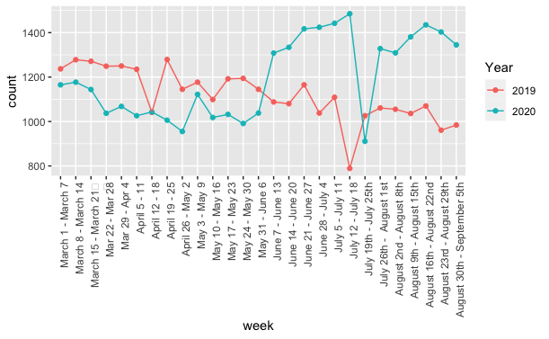

```r
p <- ggplot(crisis, aes(x=week, y=count, group=Year)) +
  geom_point(aes(color=Year)) +
  geom_line(aes(color=Year)) +
  theme(axis.text.x = element_text(angle =90, hjust = 1))

p
```

```r
# library(segmented)
# data <- crisis %>%
#   filter(Year==2020)
# my.lm <- lm(count ~ week, data = data)
# my.seg <- segmented(my.lm, seg.Z = ~ week)
# my.fitted <- fitted(my.seg)
# my.model <- data.frame(week = data$week, count = my.fitted) %>%
#   mutate(week=factor(week, levels=week_order)) %>%
#   mutate(Year=rep(2020, times=27))
# p + geom_line(my.model, mapping=aes(x=week, y=count))
```

```r
min <- crisis$count[crisis$Year==2020 & crisis$week=='May 31 - June 6']
max <- crisis$count[crisis$Year==2020 & crisis$week=='July 12 - July 18']
(max-min)/min
```

```
[1] 0.4306358
```